# COIVD-19 Analysis in US

## CMSC320 Final Project

Mukun Guo

2020.05.13

### Overview

In this tutorial, we are going to walk you through a whole pipeline of data science, that is, Data Collection and Management, Data Cleaning and Processing, Exploratory Data Analysis, and Further Analysis using machine learning and some statistics knowledge. We are going to show everyone how to create your own COVID-19 Analysis report. There are 4 sections in the tutorial

**1. Data Cleaning and Processing**

**2. Exploratory Data Analysis**

**3. Linear Regression and Hypothesis Testing**

**4. Prediction using simple Neural Net**

### Data Collection and Management

As a data scientist, one thing you should always have is a nicely formatted working directory. You will be exposed to millions of records, so it's essential that you have an organized structure to maintain all these data.

We will start our tutorial by creating a *data* folder in your working directory

```python
from pathlib import Path
Path("./data").mkdir(parents=True, exist_ok=True)
```

Now that we have a structured directory, we are going to collect our COVID-19 data. We are going to download data from this directory (https://github.com/CSSEGISandData/COVID-19) by Center for Systems Science and Engineering (CSSE) at Johns Hopkins University.

```python
import requests

filename = 'time_series_covid19_confirmed_US.csv'
print(f'Downloading {filename}')
url = f'https://raw.githubusercontent.com/CSSEGISandData/COVID-19/master/csse_covid_19_data/csse_covid_19_time_series/{filename}'
myfile = requests.get(url)
open('./data/' + filename, 'wb').write(myfile.content)
print(f'Data written to "./data/{filename}"')
```

```
Downloading time_series_covid19_confirmed_US.csv
Data written to "./data/time_series_covid19_confirmed_US.csv"
```

Now we can read our data. We have two ways to do so.

1. read from the .csv file we just create
2. read from url directly (shown below)

```python
import pandas as pd
import numpy as np
from plotnine import *
import matplotlib.pyplot as plt
import warnings
warnings.filterwarnings('ignore')

filename = 'time_series_covid19_confirmed_US.csv'
url = f'https://raw.githubusercontent.com/CSSEGISandData/COVID-19/master/csse_covid_19_data/csse_covid_19_time_series/{filename}'
df = pd.read_csv(url)
df.head(3)
```

|  | UID | iso2 | iso3 | code3 | FIPS | Admin2 | Province_State | Country_Region | Lat | Long_ | ... | 5/3/20 | 5/4/20 | 5/5/20 | 5/6/20 | 5/7/20 | 5/8/20 | 5/9/20 | 5/10/20 | 5/11/20 | 5/12/20 |
| --- | --- | --- | --- | --- | --- | --- | --- | --- | --- | --- | --- | --- | --- | --- | --- | --- | --- | --- | --- | --- | --- |
| 0 | 16 | AS | ASM | 16 | 60.0 | NaN | American Samoa | US | -14.2710 | -170.1320 | ... | 0 | 0 | 0 | 0 | 0 | 0 | 0 | 0 | 0 | 0 |
| 1 | 316 | GU | GUM | 316 | 66.0 | NaN | Guam | US | 13.4443 | 144.7937 | ... | 145 | 145 | 145 | 149 | 149 | 151 | 151 | 151 | 151 | 152 |
| 2 | 580 | MP | MNP | 580 | 69.0 | NaN | Northern Mariana Islands | US | 15.0979 | 145.6739 | ... | 14 | 14 | 14 | 15 | 15 | 15 | 16 | 16 | 19 | 19 |

3 rows × 123 columns

### Data Cleaning and Processing

```python
print(list(df.columns))
```

```
['UID', 'iso2', 'iso3', 'code3', 'FIPS', 'Admin2', 'Province_State', 'Country_Region', 'Lat', 'Long_', 'Combined_Key', '1/22/20', '1/23/20', '1/24/20', '1/25/20', '1/26/20', '1/27/20', '1/28/20', '1/29/20', '1/30/20', '1/31/20', '2/1/20', '2/2/20', '2/3/20', '2/4/20', '2/5/20', '2/6/20', '2/7/20', '…
```

The columns we will use is "Province_state" and all the columns of dates

```python
column_names = list(df.columns)

# Remove unwanted values
for name in ['UID', 'iso2', 'iso3', 'code3', 'FIPS', 'Admin2', 'Country_Region', 'Lat', 'Long_', 'Combined_Key']:
    column_names.remove(name)
covid_raw = df[column_names]

# We will create a list to record all the columns of date, this will be extremely useful soon
date_columns = list(covid_raw.columns)
date_columns.remove('Province_State')

# Aggregate rows with the same "Province_State"
aggr_dict = dict(zip(date_columns, ['sum' for _ in range(len(date_columns))]))
covid = covid_raw.groupby(['Province_State'], as_index=False).aggregate(aggr_dict)

# Create a new column of total number of cases
covid['total'] = covid[covid.columns[-1]]

# Check some basic infomation of our dataset
print("Size/Shape of the dataset: ",covid.shape)
print("Checking for null values:\n",covid.isnull().sum())
print("Checking Data-type of each column:\n",covid.dtypes)
```

```
Size/Shape of the dataset:  (58, 114)
Checking for null values:
 Province_State    0
1/22/20           0
1/23/20           0
1/24/20           0
1/25/20           0
                 ..
5/9/20            0
5/10/20           0
5/11/20           0
5/12/20           0
total             0
Length: 114, dtype: int64
Checking Data-type of each column:
 Province_State    object
1/22/20            int64
1/23/20            int64
1/24/20            int64
1/25/20            int64
                   ...
5/9/20             int64
5/10/20            int64
5/11/20            int64
5/12/20            int64
total              int64
Length: 114, dtype: object
```

One thing we notice that is good about the dataset is that it doesn't have any null values, so we doesn't have to remove null values by hand.

### Exploratory Data Analysis

Now that we are confident that we have a tidy dataset in the form of a pandas dataframe, we could start exploring the dataset.

One of the information people care about intuitively is how many people are infected with COVID-19 in each state

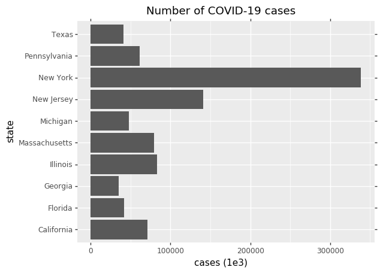

```python
# Sort and find the 10 states with the most cases
covid_sorted = covid.sort_values(by=['total'], ascending=False)
covid_10 = covid_sorted[:10]
covid_10

# Plot the 10 states
covid_10[date_columns] = covid_10[date_columns] / 1e3
(ggplot(covid_10, aes(x='Province_State', weight=covid_10.columns[-1])) +
 geom_bar() +
 coord_flip() +
 labs(y="cases (1e3)", x = "state") +
 ggtitle('Number of COVID-19 cases'))
```

Notice here the plot is ranked alphabetically, we could also rank it based on number of Covid-19 cases

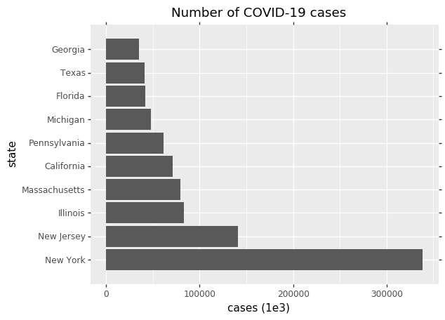

```python
# Create a new column named "rank"
covid_10['rank'] = covid_10['total'].rank(ascending=False)

# Set labels and limits
labels = list(covid_10['Province_State'])
limits = [i for i in range(covid_10.shape[0])]

# Plot graph

(ggplot(covid_10, aes(x='rank', y='total')) +
 geom_bar(stat='identity') +
 coord_flip() +
 labs(y="cases (1e3)", x = "state") +
 scale_x_discrete(name='state',  limits=limits, labels=labels) +
 ggtitle('Number of COVID-19 cases'))
```

Another thing people would really like to learn about is the trend of Covid-19 cases in their home state (region), we will, for instance, look into the trend in Maryland

```python
# Extract data of Maryland
maryland = covid[covid['Province_State'] == 'Maryland']
maryland
```

|  | Province_State | 1/22/20 | 1/23/20 | 1/24/20 | 1/25/20 | 1/26/20 | 1/27/20 | 1/28/20 | 1/29/20 | 1/30/20 | ... | 5/4/20 | 5/5/20 | 5/6/20 | 5/7/20 | 5/8/20 | 5/9/20 | 5/10/20 | 5/11/20 | 5/12/20 | total |
| --- | --- | --- | --- | --- | --- | --- | --- | --- | --- | --- | --- | --- | --- | --- | --- | --- | --- | --- | --- | --- | --- |
| 24 | Maryland | 0 | 0 | 0 | 0 | 0 | 0 | 0 | 0 | 0 | ... | 26408 | 27117 | 28163 | 29374 | 30485 | 31534 | 32587 | 33373 | 34061 | 34061 |

1 rows × 114 columns

To plot out our graph, we need to make some modification to the maryland dataset first. Sepcifically, instead of date being the column names, we want to have a column with name "date", and another column with name "cases". This will make our life much simpler when trying to plot the graph. To do so, we will use the pandas `stack()` function

```python
# Reshape the dataframe, remove the first row ('Maryland'), remove useless column(s)
maryland_stacked = pd.DataFrame(maryland.stack()[1:])
maryland_stacked = maryland_stacked.reset_index()
maryland_stacked.columns = ['dummy', 'date', 'cases']
maryland_stacked = maryland_stacked[['date', 'cases']]

# Remove all the zero values
maryland_stacked = maryland_stacked[maryland_stacked['cases'] != 0]

maryland_stacked
```

|  | date | cases |
| --- | --- | --- |
| 44 | 3/6/20 | 3 |
| 45 | 3/7/20 | 3 |
| 46 | 3/8/20 | 5 |
| 47 | 3/9/20 | 5 |
| 48 | 3/10/20 | 8 |
| ... | ... | ... |
| 108 | 5/9/20 | 31534 |
| 109 | 5/10/20 | 32587 |
| 110 | 5/11/20 | 33373 |
| 111 | 5/12/20 | 34061 |
| 112 | total | 34061 |

69 rows × 2 columns

Now that we have the dataset in the shape we want, we can start plotting its trend. Note that the "dummy" columns is the index for "maryland" and we won't be using it.

[figure not shown]

```python
# Plot its trend using a line plot
plt.plot(maryland_stacked['cases'])
plt.ylabel('number of cases')
# plt.xticks([])
plt.xticks(np.arange(40, 115, 15), ['Jan', 'Feb', 'Mar', 'Apri', 'May'])
plt.title('Number of COVID-19 cases in Maryland')
plt.show()
```

As we can see in the above graph, the number of cases was (almost) increasing exponentially, but recently it starts to slow down. We could verify this by looking at its log transformation

[figure not shown]

```python
# Plot its trend using a line plot
plt.plot(maryland_stacked['cases'])
plt.yscale('log')
plt.ylabel('log number of cases')
# plt.xticks([])
plt.xticks(np.arange(40, 115, 15), ['Jan', 'Feb', 'Mar', 'Apri', 'May'])
plt.title('Number of COVID-19 cases in Maryland after log transformation')
plt.show()
```

This verified our assumption that COVID-19 cases in Maryland was increasing exponentially at the beginning, is now gradually slowing down, which is a good sign.

### Linear Regression and Hypothesis Testing

One thing we would really like to know is the future trend of the COVID-19 pandemics. In this section, we will introduce how to perform simple machine learning algorithm on this dataset to predict the future trend. We will also perform hypothesis testing to decide whether our result is statistically significant and hence can be trustworthy.

To start with, let's first decide what are the states that we are interested in. For instance, I will pick Maryland, New York, and California. Let's start with extracting data of the three states.

```python
# Extract data of Maryland, New York, and California
md = covid[covid['Province_State'] == 'Maryland']
ny = covid[covid['Province_State'] == 'New York']
ca = covid[covid['Province_State'] == 'California']

md.head()
```

|  | Province_State | 1/22/20 | 1/23/20 | 1/24/20 | 1/25/20 | 1/26/20 | 1/27/20 | 1/28/20 | 1/29/20 | 1/30/20 | ... | 5/4/20 | 5/5/20 | 5/6/20 | 5/7/20 | 5/8/20 | 5/9/20 | 5/10/20 | 5/11/20 | 5/12/20 | total |
| --- | --- | --- | --- | --- | --- | --- | --- | --- | --- | --- | --- | --- | --- | --- | --- | --- | --- | --- | --- | --- | --- |
| 24 | Maryland | 0 | 0 | 0 | 0 | 0 | 0 | 0 | 0 | 0 | ... | 26408 | 27117 | 28163 | 29374 | 30485 | 31534 | 32587 | 33373 | 34061 | 34061 |

1 rows × 114 columns

Similar to the section of analysising past trend, we first need to reshape the datasets into shapes we want - with dates and cases being two seperated columns. But before doing that, we first need to be clear in mind about what are we going to do. So here's what we are gonna do.

1. Reorganize the dataset, remove useless information
2. Perform a regression machine learning algorithm since we want to tackle a prediction task
3. Perform hypothesis testing to decide whether the result is statistically significant

Wonderful! Now that we understand our tasks, let\'s think more about the regression algorithm, we will use linear regression to predict future case number.

Now let's start by reorganizing the dataset

```python
# Reshape the dataframe, remove the first row , remove useless column(s)
md_stacked = pd.DataFrame(md.stack()[1:])
md_stacked = md_stacked.reset_index()
md_stacked.columns = ['dummy', 'date', 'cases']
md_stacked = md_stacked[['date', 'cases']]

ny_stacked = pd.DataFrame(ny.stack()[1:])
ny_stacked = ny_stacked.reset_index()
ny_stacked.columns = ['dummy', 'date', 'cases']
ny_stacked = ny_stacked[['date', 'cases']]

ca_stacked = pd.DataFrame(ca.stack()[1:])
ca_stacked = ca_stacked.reset_index()
ca_stacked.columns = ['dummy', 'date', 'cases']
ca_stacked = ca_stacked[['date', 'cases']]
```

Then we create a new dataframe with three columns ['state', 'date', 'cases'] by concatenate the three stacked dataframe. It will be helpful to our analysis

```python
# Add a new column to each stacked dataframe
md_stacked['state'] = 'MD'
ny_stacked['state'] = 'NY'
ca_stacked['state'] = 'CA'

concat_df = pd.concat([ca_stacked, ny_stacked, md_stacked], ignore_index=True)
concat_df
```

|  | date | cases | state |
| --- | --- | --- | --- |
| 0 | 1/22/20 | 0 | CA |
| 1 | 1/23/20 | 0 | CA |
| 2 | 1/24/20 | 0 | CA |
| 3 | 1/25/20 | 0 | CA |
| 4 | 1/26/20 | 2 | CA |
| ... | ... | ... | ... |
| 334 | 5/9/20 | 31534 | MD |
| 335 | 5/10/20 | 32587 | MD |
| 336 | 5/11/20 | 33373 | MD |
| 337 | 5/12/20 | 34061 | MD |
| 338 | total | 34061 | MD |

339 rows × 3 columns

Let's first gain some insight of the situation in the three states by plotting out their number of cases. We notice that for each state, there are more than 100 days of data, which is too many for our plot to be intuitive. So we are going to sample out some dates first. To achieve this, we can devide our work into following steps

1. Get number of dates
2. Create sample index
3. Extract samples using the sample index

```python
# Get number of dates
dim = concat_df.shape
n_dates = dim[0]
n_dates /= 3

# Create sample index
n_samples = 20
sample_idx = list(np.arange(0, n_dates, n_dates // n_samples))
sample_idx = sample_idx + [i + n_dates for i in sample_idx] + [i + 2*n_dates for i in sample_idx]

# Extract samples
sample_df = concat_df.iloc[sample_idx]
sample_df.head(3)
```

|  | date | cases | state |
| --- | --- | --- | --- |
| 0 | 1/22/20 | 0 | CA |
| 5 | 1/27/20 | 2 | CA |
| 10 | 2/1/20 | 3 | CA |

Let's make sure the data type is correct

```python
print("Checking Data-type of each column:\n",sample_df.dtypes)
```

```
Checking Data-type of each column:
 date     object
cases    object
state    object
dtype: object
```

Oops, we want to change "date" to string, "state" to string, and cases to "int"

```python
sample_df['date'] = sample_df['date'].astype('str')
sample_df['state'] = sample_df['state'].astype('str')
sample_df['cases'] = sample_df['cases'].astype('int32')
```

Let's plot our data! Since we want to see number of cases across time in each state, we are going to use a scatter plot with color encoding state

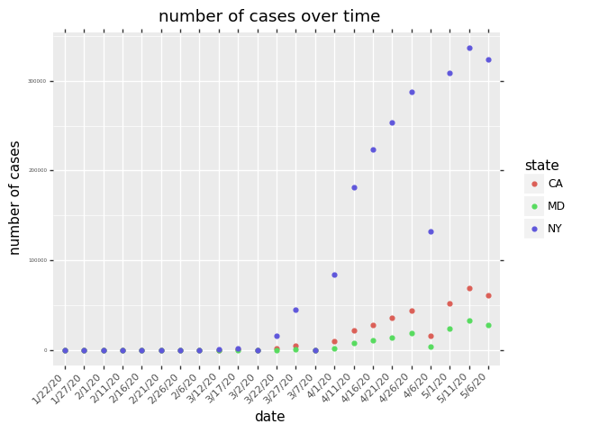

```python
(ggplot(sample_df, aes(x='date', y='cases')) +
 geom_point(aes(color='state')) +
 theme(axis_text_x=element_text(angle=45,hjust=1, size=8)) +
 theme(axis_text_y=element_text(hjust=1, size=4)) +
 labs(y="number of cases", x = "date", title='number of cases over time'))
```

We notice this is a bit strange since number of cases should be monotone-increasing. By observing the x-axis we notice the order of date is incorrect. Now we try to fix it

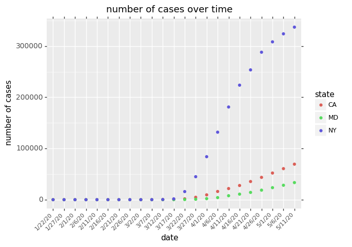

```python
# Extract dates
dates = list(sample_df['date'])
# Remove duplicate value
dates = list(dict.fromkeys(dates))

# Create rank column
dates_idx = list(range(len(dates)))
dates_idx = [i+1 for i in dates_idx]
def date2value(date):
    month, day, year = date.split('/')
    val = 0
    val += 10000 * int(year)
    val += 100 * int(month)
    val += int(day)
    return val

dates_idx.sort(key=lambda x: date2value(dates[x-1]))
sample_df['rank'] = dates_idx * 3

# Plot
limits = [i for i in range(len(dates_idx))]

(ggplot(sample_df, aes(x='rank', y='cases', color='state')) +
 geom_point() +
 scale_x_discrete(name='date',  limits=limits, breaks=lambda x: [i for i in x], labels=dates) +
 theme(axis_text_x=element_text(angle=45, hjust=1, size=8)) +
 theme(axis_text_y=element_text(hjust=1, size=10)) +
 labs(y="number of cases", x = "date", title='number of cases over time'))
```

Let's now fit a regression line to them

```python
print("Checking Data-type of each column:\n",sample_df.dtypes)
```

```
Checking Data-type of each column:
 date     object
cases     int32
state    object
rank      int64
dtype: object
```

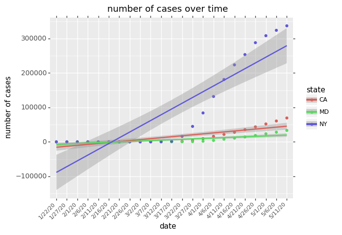

```python
(ggplot(sample_df, aes(x='rank', y='cases', color='state' )) +
 geom_point() +
 geom_smooth(method='lm') +
 scale_x_discrete(name='date',  limits=limits, labels=dates) +
 theme(axis_text_x=element_text(angle=45,hjust=1, size=8)) +
 theme(axis_text_y=element_text(hjust=1, size=10)) +
 labs(y="number of cases", x = "date", title='number of cases over time'))
```

We could tell by eyes that this is not a good linear regression fit. For now we will accept it as we first want to answer the question that whether number of COVID-19 cases is positively correlated to time. In other words, is it constantly increasing. Intuitively, the answer seems obvious, but as a data scientist, we can perform hypothesis testing to tell whether the result is statistically significant. We will do the following steps.

1. Have a null hypothesis that there is no relationship between time and number of cases
2. compute the p-value, the probability that of which oberving an increase under the null assumption.
3. Reject or accept our null hypothesis

We first extract Maryland data and make the same plot as above.

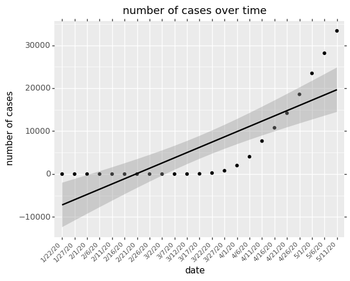

```python
md_sample = sample_df[sample_df['state']=='MD']

(ggplot(md_sample, aes(x='rank', y='cases' )) +
 geom_point() +
 geom_smooth(method='lm') +
 scale_x_discrete(name='date',  limits=limits, labels=dates) +
 theme(axis_text_x=element_text(angle=45,hjust=1, size=8)) +
 theme(axis_text_y=element_text(hjust=1, size=10)) +
 labs(y="number of cases", x = "date", title='number of cases over time'))
```

The above graph is plotted using "samples" of the original dataset, we DO have a lot of extra data to have a more accurate linear regression. Recall all data of Maryland is stored in a variable named `md_stacked` We can do this using the `statsmodels.formula.api` package (**Note that we have replace "date" column with "rank", but since date can be regarded as categorical attributes, such amendment will not affect our result**)

Let's start with preprocess all our Maryland data. Similarly, we will create a rank column to replace the original date column as date incurs ordering issues

```python
# Get all maryland sample
md_regr = md_stacked[md_stacked['date'] != 'total']

# Fix data type
md_regr['cases'] = md_regr['cases'].astype('int32')

# remove 0 values
md_regr = md_regr[md_regr['cases'] != 0]

# Extract dates
dates = list(md_regr['date'])

# Create rank column
dates_idx = list(range(len(dates)))
dates_idx = [i+1 for i in dates_idx]
dates_idx.sort(key=lambda x: date2value(dates[x-1]))
md_regr['rank'] = dates_idx

md_regr.head()
```

|  | date | cases | state | rank |
| --- | --- | --- | --- | --- |
| 44 | 3/6/20 | 3 | MD | 1 |
| 45 | 3/7/20 | 3 | MD | 2 |
| 46 | 3/8/20 | 5 | MD | 3 |
| 47 | 3/9/20 | 5 | MD | 4 |
| 48 | 3/10/20 | 8 | MD | 5 |

```python
import statsmodels.formula.api as sm

regr = sm.ols('cases~rank', data=md_regr).fit()
regr.params
```

```
Intercept   -7864.406058
rank          518.481506
dtype: float64
```

So here our regression tells us on average we have 518 new cases every day. But is this result statistically significant? Now we need to calculate it's p-value, the probability of which oberving an increase of 518 or greater under the null assumption.

```python
regr.pvalues
```

```
Intercept    2.405677e-12
rank         1.278666e-32
dtype: float64
```

We see that it has a p-value of 1.27e-32, (which is almost 0), so we can reject the null hypothesis, and hence claim that our result of number of COVID-19 cases is positively correlated to date is statistically significant

### Prediction using simple Neural Nets

In the last section, we have shown there is a positive correlation between time and number of COVID-19 cases. However, linear regression failed to give us a precise prediction of future cases. Hence, in this section, we will explore a more powerful tool, Nerual Networks.

As usual, we first need to prepare our dataset. Our goal is to predict the number of cases in future 10 days. To verify how good our model is, we will use all but the last 10 day of data as our training set, the rest as our test set.

```python
# Get our training data
md_nn = md_regr

x = np.array(md_nn['rank'].iloc[:-10]).reshape(-1, 1)
y = np.array(md_nn['cases'].iloc[:-10])

# Prepare test data
test_x = np.array(md_nn['rank'].iloc[-10:]).reshape(-1, 1)
true_y = np.array(md_nn['cases'].iloc[-10:])
```

Now we are going to train the neural network. The package we are going to use is `sklearn.neural_network.MLPRegressor`

```python
from sklearn.neural_network import MLPRegressor


nn = MLPRegressor(
    hidden_layer_sizes=(10,),  activation='relu', solver='adam', alpha=0.001, batch_size='auto',
    learning_rate='constant', learning_rate_init=0.05, power_t=0.5, max_iter=10000, shuffle=True,
    random_state=9, tol=0.0001, verbose=False, warm_start=False, momentum=0.9, nesterovs_momentum=True,
    early_stopping=False,  beta_1=0.9, beta_2=0.999, epsilon=1e-08)

n = nn.fit(x, y)
```

Let's do the prediction and plot the result.

- training data is represented in blue
- our prediction is in red
- true data is in green

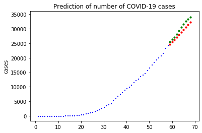

```python
test_y = nn.predict(test_x)
fig = plt.figure()
ax1 = fig.add_subplot(111)
ax1.scatter(x, y, s=1, c='b', marker="s", label='real')
ax1.scatter(test_x, test_y, s=10, c='r', marker="o", label='NN Prediction')
ax1.scatter(test_x, true_y, s=10, c='g', marker="o", label='true')
ax1.set_ylabel('cases')
ax1.set_title('Prediction of number of COVID-19 cases')
plt.show()
```

Intuitively, the nn regression did a really good job. Now let's calculate its abosolute error

```python
for i in test_x:
    i = i[0]
    date = md_nn[md_nn['rank'] == i].iloc[0]['date']
    idx = i - max(x) - 1
    true = int(true_y[idx])
    pred = int(test_y[idx])
    error = abs(pred - true)
    print(f'[{date}]\nTrue: {true:,}\nPrediction: {pred:,}\n Absolute Error: {error}\n Error rate: {error/true:.4f}')
    print('--------')
```

```
[5/3/20]
True: 25,462
Prediction: 24,579
 Absolute Error: 883
 Error rate: 0.0347
--------
[5/4/20]
True: 26,408
Prediction: 25,432
 Absolute Error: 976
 Error rate: 0.0370
--------
[5/5/20]
True: 27,117
Prediction: 26,285
 Absolute Error: 832
 Error rate: 0.0307
--------
[5/6/20]
True: 28,163
Prediction: 27,138
 Absolute Error: 1025
 Error rate: 0.0364
--------
[5/7/20]
True: 29,374
Prediction: 27,990
 Absolute Error: 1384
 Error rate: 0.0471
--------
[5/8/20]
True: 30,485
Prediction: 28,843
 Absolute Error: 1642
 Error rate: 0.0539
--------
[5/9/20]
True: 31,534
Prediction: 29,696
 Absolute Error: 1838
 Error rate: 0.0583
--------
[5/10/20]
True: 32,587
Prediction: 30,549
 Absolute Error: 2038
 Error rate: 0.0625
--------
[5/11/20]
True: 33,373
Prediction: 31,402
 Absolute Error: 1971
 Error rate: 0.0591
--------
[5/12/20]
True: 34,061
Prediction: 32,254
 Absolute Error: 1807
 Error rate: 0.0531
--------
```

we can also calculate the average error across the ten days.

```python
print(f'{sum(abs(test_y - true_y.ravel()) / true_y.ravel()) / 10:.4f}')
```

```
0.0472
```

We have an average error rate of about 4.7%, which is quite amazing. And this conclude our data science tutorial

### Conclusion

In this tutorial, we have gone through the basic pipeline of data science practice, which includes

1. Data Cleaning and Processing
2. Exploratory Data Analysis
3. Linear Regression and Hypothesis Testing
4. Prediction using simple Neural Net We hope the our tutorial can help every reader gain some insight of the current COVID-19 situation. And we wish everyone stay well in this trying time.

If you have any question regarding this tutorial, please email guomukun@umd.edu